# workbook-mjg

# 5 Chapter 5; Multi-part Plots

## 5.1 Interaction plots

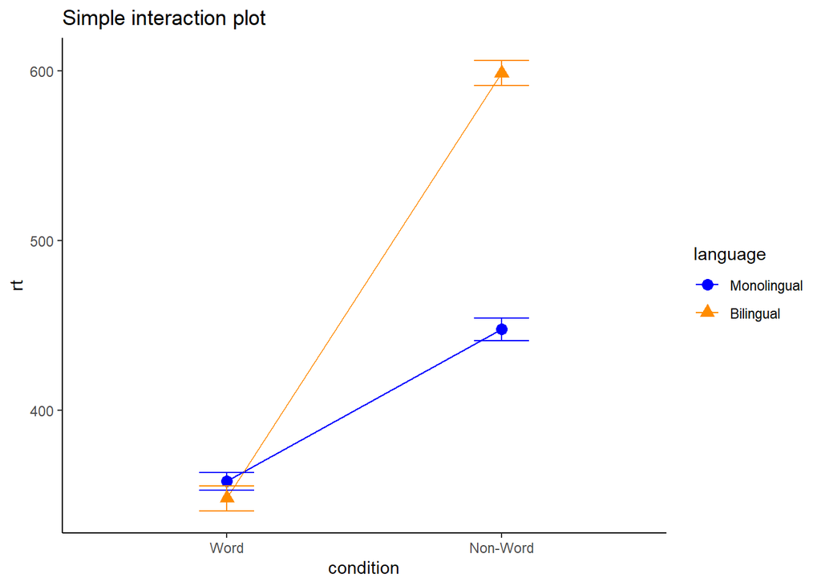

```r
ggplot(dat_long, aes(x = condition, y = rt,
                     shape = language,
                     group = language,
                     color = language)) +
  stat_summary(fun = "mean", geom = "point", size = 3) +
  stat_summary(fun = "mean", geom = "line") +
  stat_summary(fun.data = "mean_se", geom = "errorbar", width = .2) +
  scale_color_manual(values = c("blue", "darkorange")) +
  theme_classic() +
  labs(title = "Simple interaction plot")
```

## 5.2 Combined interaction plots

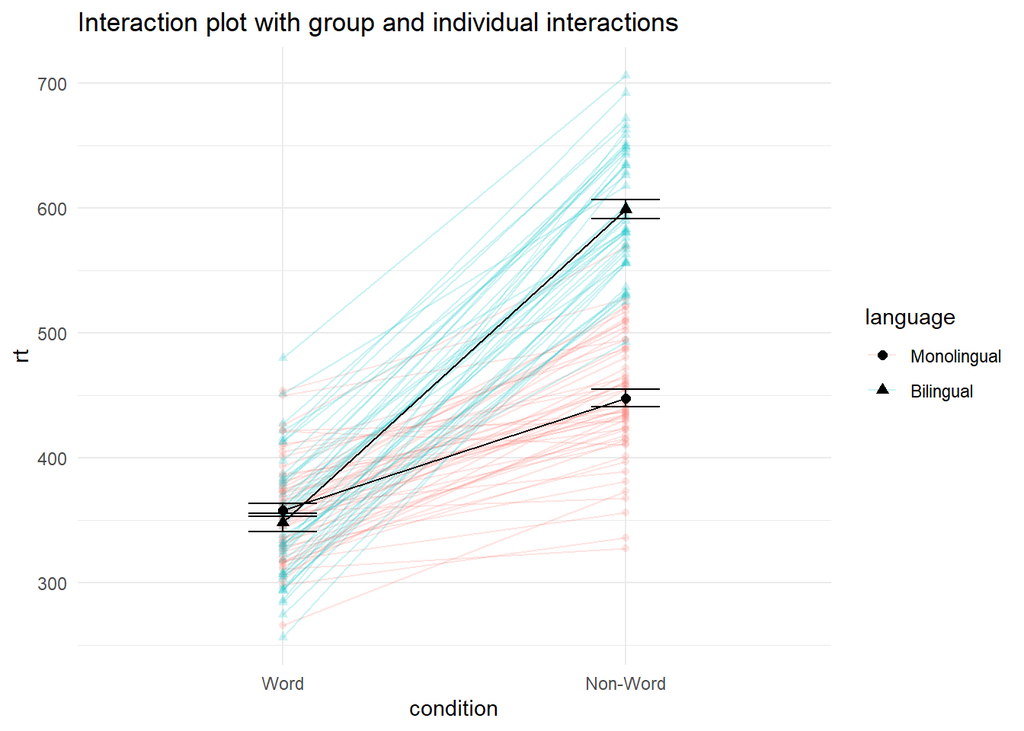

```r
ggplot(dat_long, aes(x = condition, y = rt, group = language, shape = language)) +
  geom_point(aes(colour = language),alpha = .2) +
  geom_line(aes(group = id, colour = language), alpha = .2) +
   stat_summary(fun = "mean", geom = "point", size = 2, colour = "black") +
  stat_summary(fun = "mean", geom = "line", colour = "black") +
  stat_summary(fun.data = "mean_se", geom = "errorbar", width = .2, colour = "black") +
  theme_minimal() +
  labs(title = "Interaction plot with group and individual interactions")
```

## 5.3 Facets

Faceted scatterplots

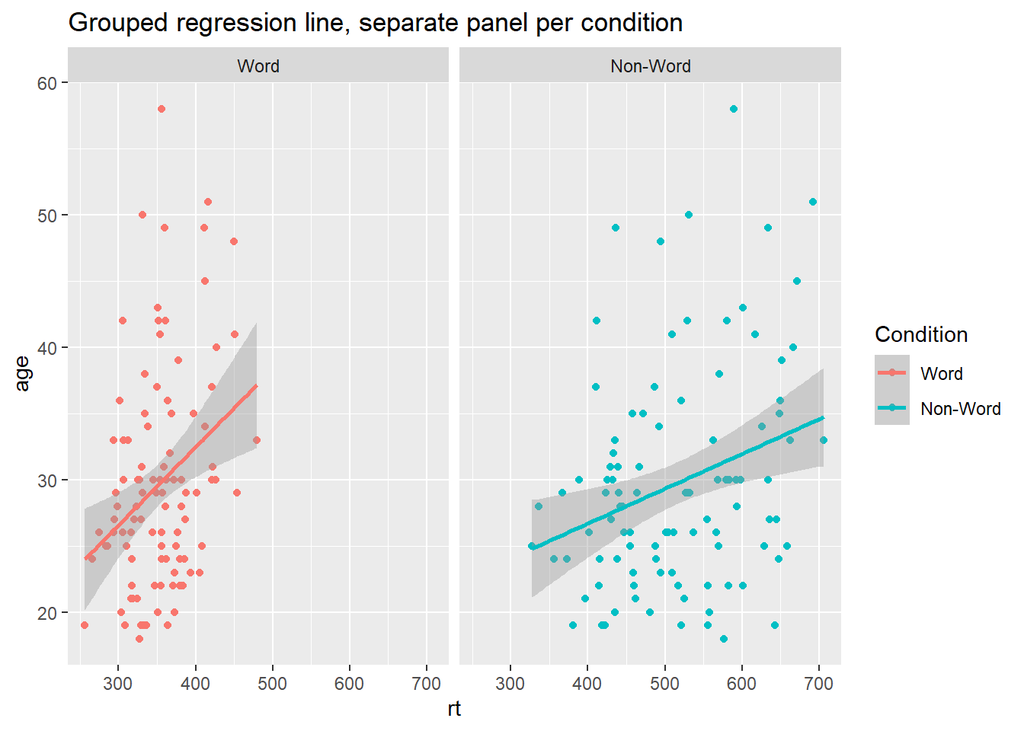

```r
ggplot(dat_long, aes(x = rt, y = age, color=condition)) +
  geom_point() +
  geom_smooth(method = "lm") +
  facet_wrap(~condition) +
  scale_color_discrete(name = "Condition") +
  labs(title = "Grouped regression line, separate panel per condition")
```

Faceted violin-boxplots

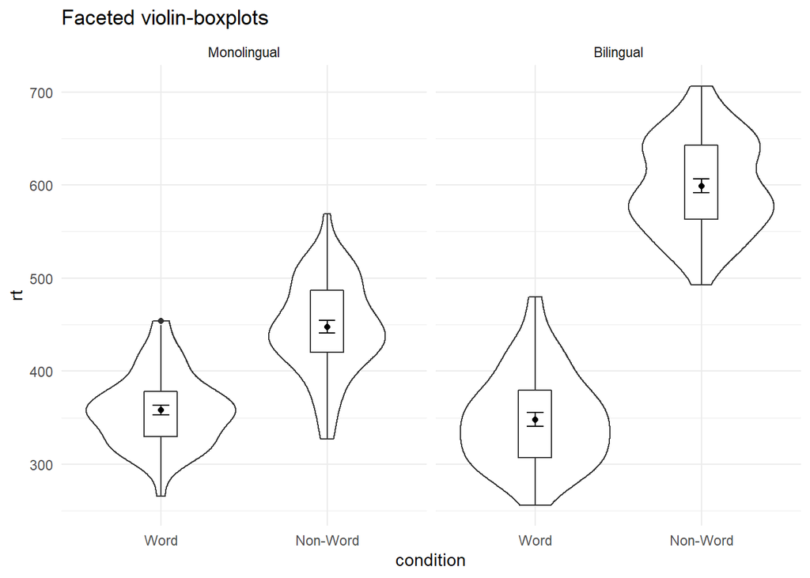

```r
ggplot(dat_long, aes(x = condition, y= rt)) +
  geom_violin() +
  geom_boxplot(width = .2, fatten = NULL) +
  stat_summary(fun = "mean", geom = "point") +
  stat_summary(fun.data = "mean_se", geom = "errorbar", width = .1) +
  facet_wrap(~language) +
  theme_minimal() +
  labs(title = "Faceted violin-boxplots")
```

## 5.4 Storing plots as variables

```r
p1 <- ggplot(dat_long, aes(x = rt)) +
  geom_histogram(binwidth = 10, color = "black") +
  labs(title = "RT histogram")

p2 <- ggplot(dat_long, aes(x = acc)) +
  geom_histogram(binwidth = 1, color = "black")  +
  labs(title = "Accuracy histogram")
```

```r
p3 <- p2 + theme_minimal() + labs(title = "Accuracy histogram with minimal theme")
```

## 5.5 Saving plots as png files

```r
ggsave(filename = "my_plot.png") # save last displayed plot
```

```r
ggsave(filename = "my_plot.png", plot = p3) # save plot p3
```

## 5.6 Mulitple plots

### 5.6.1 Combining two plots

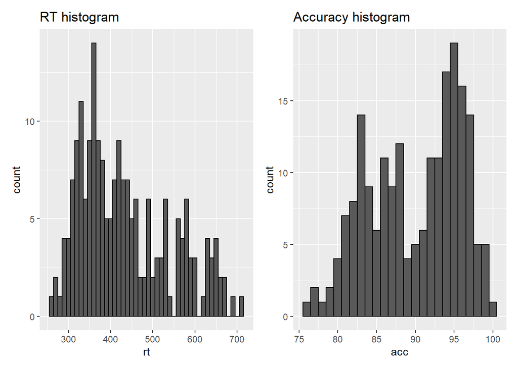

```r
p1 + p2 # side-by-side
```

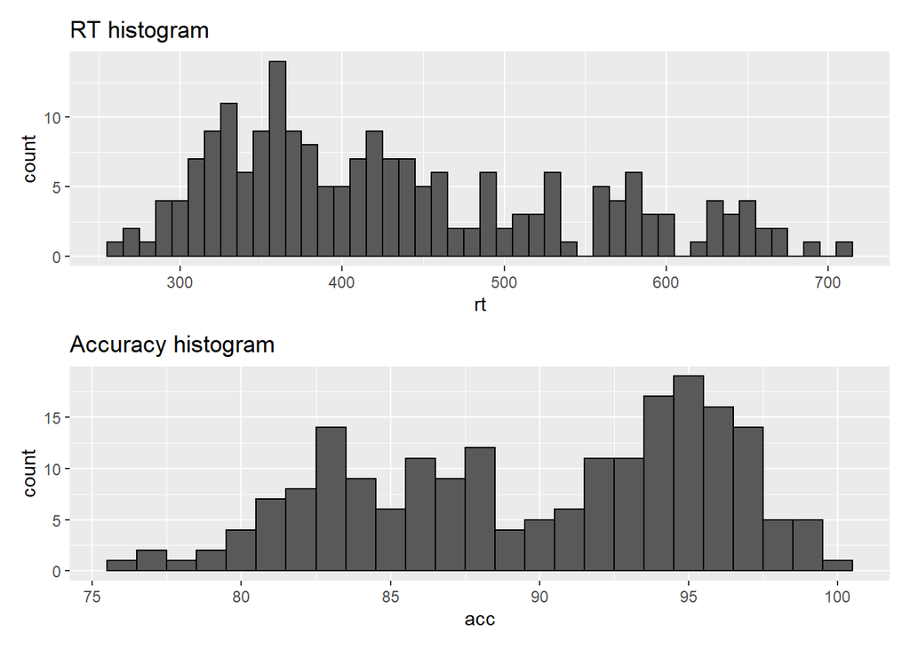

```r
p1 / p2 # stacked
```

### 5.6.2 Combining three or more plots

```r
p5 <- ggplot(dat_long, aes(x = condition, y = rt, group = language, shape = language)) +
  geom_point(aes(colour = language),alpha = .2) +
  geom_line(aes(group = id, colour = language), alpha = .2) +
  stat_summary(fun = "mean", geom = "point", size = 2, colour = "black") +
  stat_summary(fun = "mean", geom = "line", colour = "black") +
  stat_summary(fun.data = "mean_se", geom = "errorbar", width = .2, colour = "black") +
  theme_minimal() +
  labs(title = "Interaction plot with group and individual interactions")
```

```r
p6 <- ggplot(dat_long, aes(x = condition, y= rt)) +
  geom_violin() +
  geom_boxplot(width = .2, fatten = NULL) +
  stat_summary(fun = "mean", geom = "point") +
  stat_summary(fun.data = "mean_se", geom = "errorbar", width = .1) +
  facet_wrap(~language)+
  theme_minimal() +
  labs(title = "Facetted violin-boxplots")
```

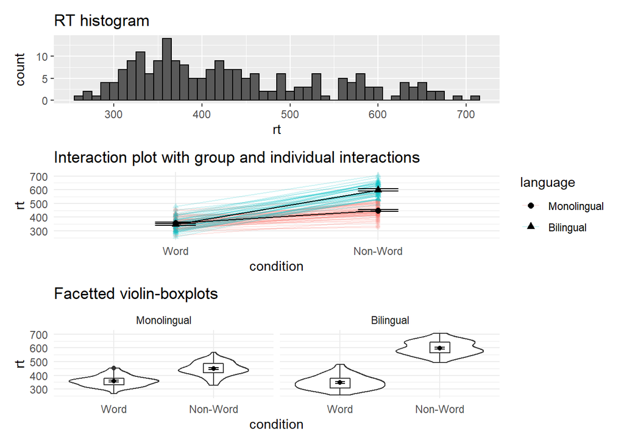

```r
p1 /p5 / p6
```

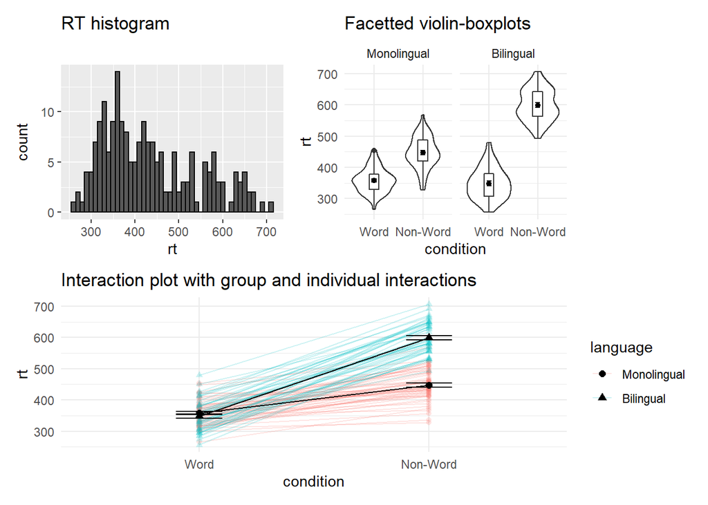

```r
(p1 + p6) / p5
```

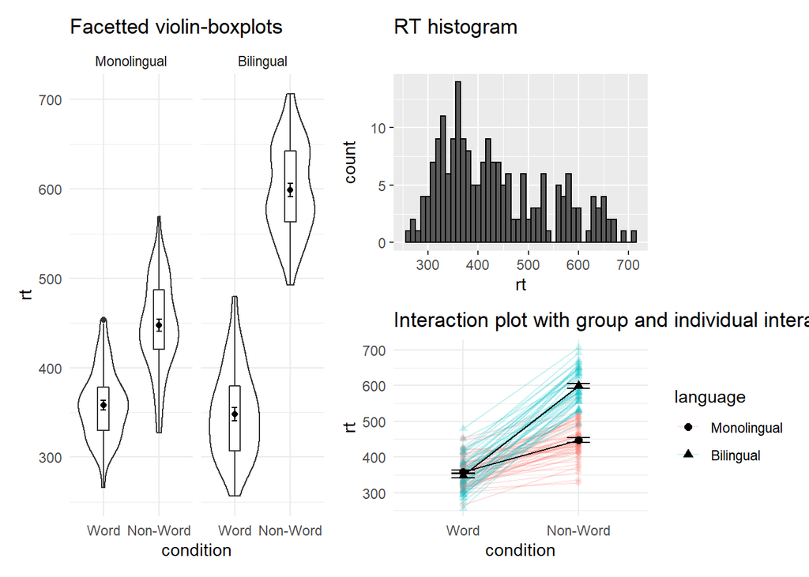

```r
p6 | p1 / p5
```

## 5.7 Customisation 4

### 5.7.1 Axis labels

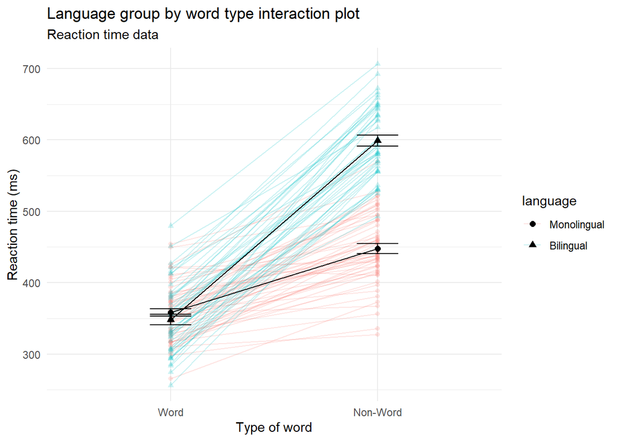

```r
p5 + labs(x = "Type of word",
          y = "Reaction time (ms)",
          title = "Language group by word type interaction plot",
          subtitle = "Reaction time data")
```

### 5.7.2 Redundant aesthetics

With redundant legend

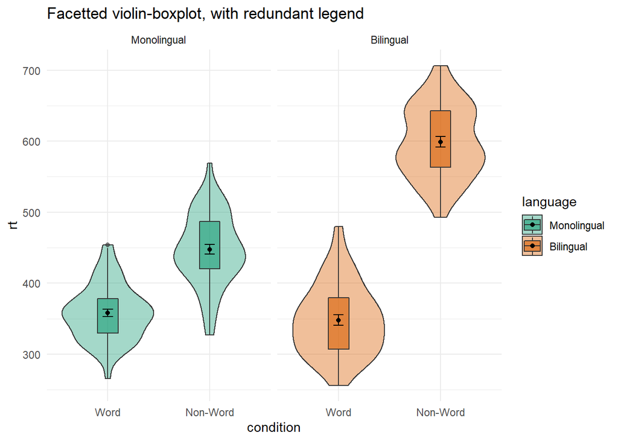

```r
ggplot(dat_long, aes(x = condition, y= rt, fill = language)) +
  geom_violin(alpha = .4) +
  geom_boxplot(width = .2, fatten = NULL, alpha = .6) +
  stat_summary(fun = "mean", geom = "point") +
  stat_summary(fun.data = "mean_se", geom = "errorbar", width = .1) +
  facet_wrap(~language)+
  theme_minimal() +
  scale_fill_brewer(palette = "Dark2") +
  labs(title = "Facetted violin-boxplot, with redundant legend")
```

Without redundant legend

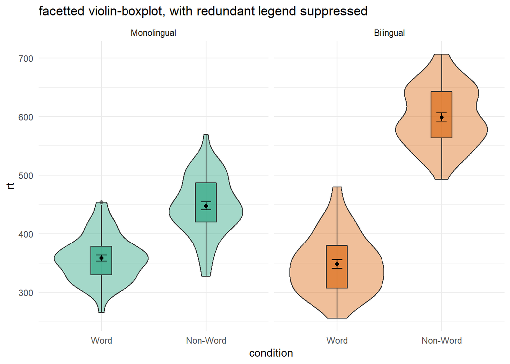

```r
ggplot(dat_long, aes(x = condition, y= rt, fill = language)) +
  geom_violin(alpha = .4) +
  geom_boxplot(width = .2, fatten = NULL, alpha = .6) +
  stat_summary(fun = "mean", geom = "point") +
  stat_summary(fun.data = "mean_se", geom = "errorbar", width = .1) +
  facet_wrap(~language)+
  theme_minimal() +
  scale_fill_brewer(palette = "Dark2") +
  guides(fill = "none") +
  labs(title = "facetted violin-boxplot, with redundant legend suppressed")
```

## 5.8 Activites 4

For solutions see [this link to the website](https://psyteachr.github.io/introdataviz/multi-part-plots.html#activities-4)

1. Rather than mapping both variables (condition and language) to a single interaction plot with individual participant data, instead produce a faceted plot that separates the monolingual and bilingual data. All visual elements should remain the same (colours and shapes) and you should also take care not to have any redundant legends.

```r
# put answer to 1 here
```

2. Choose your favourite three plots you’ve produced so far in this tutorial, tidy them up with axis labels, your preferred colour scheme, and any necessary titles, and then combine them using patchwork. If you’re feeling particularly proud of them, post them on Twitter using #PsyTeachR.

```r
# put answer to 2 here
```

# 6 Appendices

## 6.1 Additional resources

There are a number of incredible open-access online resources that, using the skills you have developed in this tutorial, will allow you to start adapting your figures and plots to make them as informative as possible for your reader. Additionally, there are also many excellent resources that expand on some of the topics we have covered here briefly, particularly data wrangling, that can help you consolidate and expand your skill set.

**PsyTeachR**

The [psyTeachR](https://psyteachr.github.io/) team at the University of Glasgow School of Psychology and Neuroscience has successfully made the transition to teaching reproducible research using R across all undergraduate and postgraduate levels. Our curriculum now emphasizes essential ‘data science’ graduate skills that have been overlooked in traditional approaches to teaching, including programming skills, data visualisation, data wrangling and reproducible reports. Students learn about probability and inference through data simulation as well as by working with real datasets. These materials cover all the functions we have used in this tutorial in more depth and all have Creative Commons licences to allow their use and reuse without attribution.

- [Applied Data Skills](https://psyteachr.github.io/ads/)
- [Level 1 Data Skills](https://psyteachr.github.io/data-skills/)
- [Level 2 Analyses](https://psyteachr.github.io/analysis/)
- [Level 3 Statistical Models](https://psyteachr.github.io/stat-models/)
- [Msc Fundamentals of Quantititive Analysis](https://psyteachr.github.io/fun-quant/)
- [MSc Data Skills for Reproducible Research](https://psyteachr.github.io/reprores/)

**Installing R and RStudio**

- [Installing R - PsyTeachR](https://psyteachr.github.io/data-skills-v1/installing-r.html)
- [Running R on your own computer (walkthrough videos) - Danielle Navarro](https://www.youtube.com/playlist?list=PLRPB0ZzEYegOZivdelOuEn-R-XUN-DOjd)

**Intro to R and RStudio**

- RStudio Essentials: [Programming - Part 1 (Writing code in RStudio)](https://www.rstudio.com/resources/webinars/programming-part-1-writing-code-in-rstudio/)
- RStudio Essentials: [Programming - Part 2 (Debugging code in RStudio)](https://www.rstudio.com/resources/webinars/programming-part-2-debugging-code-in-rstudio/)

**R Markdown**

- [Introduction to R Markdown](https://rmarkdown.rstudio.com/lesson-1.html)
- [R Markdown: The Definitive Guide](https://bookdown.org/yihui/rmarkdown/)

**Data wrangling**

- [R for Data Science](https://r4ds.had.co.nz/)
- [Text Mining with R](https://www.tidytextmining.com/)

**Data visualisation**

- [R Graph Gallery](https://www.r-graph-gallery.com/)
- [Fundamentals of Data Vizualisation](https://clauswilke.com/dataviz/)
- [Data Vizualisation: A Practical Introduction](https://socviz.co/)
- [Look at Data](https://socviz.co/lookatdata.html) from [Data Vizualization for Social Science](http://socviz.co/)
- Graphs in *Cookbook for R*
- [Top 50 ggplot2 Visualizations](http://r-statistics.co/Top50-Ggplot2-Visualizations-MasterList-R-Code.html)
- [R Graphics Cookbook](http://www.cookbook-r.com/Graphs/) by Winston Chang
- [ggplot extensions](https://exts.ggplot2.tidyverse.org/)
- [plotly](https://plot.ly/ggplot2/) for creating interactive graphs
- [Drawing Beautiful Maps Programmatically](https://r-spatial.org/r/2018/10/25/ggplot2-sf.html)
- [gganimate](https://gganimate.com/)